**Prediction of Weightlifting Training Quality**

**Background**

Using devices such as Jawbone Up, Nike FuelBand, and Fitbit it is now possible to collect a large amount of data about personal activity relatively inexpensively. One thing that people regularly do is quantify how much of a particular activity they do, but they rarely quantify how well they do it. In this project, we use data from accelerometers on the belt, forearm, arm, and dumbell of 6 participants. They were asked to perform barbell lifts correctly and incorrectly in 5 different ways. The data collected is analyzed to predict which of these participants performed the exercise correctly.

**Data Preparation**

Both the training data and test data have been provided. We will load the data and get it ready for analysis. The training dataset is *harTrain* and the testdataset is *harTest*

```r
harTest <- read.csv(file="pml-testing.csv",header=TRUE,sep=",")
harTrain <- read.csv(file="pml-training.csv",header=TRUE,sep=",")

# The data consists of 160 predictors. Of these only 56 attributes has raw data, the remainder has derived data like skewness, variance, mean etc.
# Filter out all derived and second order attributes from the data sets.

rawvars <- c( 2,3,4, 8:11 , 37:49, 60:68,84:86, 102, 113:124, 140, 151:160)

filter_harTest <- harTest[rawvars]
filter_harTrain <- harTrain[rawvars]

# Test Attributes of interest

names(filter_harTrain)
```

```
##  [1] "user_name"            "raw_timestamp_part_1" "raw_timestamp_part_2"
##  [4] "roll_belt"            "pitch_belt"           "yaw_belt"
##  [7] "total_accel_belt"     "gyros_belt_x"         "gyros_belt_y"
## [10] "gyros_belt_z"         "accel_belt_x"         "accel_belt_y"
## [13] "accel_belt_z"         "magnet_belt_x"        "magnet_belt_y"
## [16] "magnet_belt_z"        "roll_arm"             "pitch_arm"
## [19] "yaw_arm"              "total_accel_arm"      "gyros_arm_x"
## [22] "gyros_arm_y"          "gyros_arm_z"          "accel_arm_x"
## [25] "accel_arm_y"          "accel_arm_z"          "magnet_arm_x"
## [28] "magnet_arm_y"         "magnet_arm_z"         "roll_dumbbell"
## [31] "pitch_dumbbell"       "yaw_dumbbell"         "total_accel_dumbbell"
## [34] "gyros_dumbbell_x"     "gyros_dumbbell_y"     "gyros_dumbbell_z"
## [37] "accel_dumbbell_x"     "accel_dumbbell_y"     "accel_dumbbell_z"
## [40] "magnet_dumbbell_x"    "magnet_dumbbell_y"    "magnet_dumbbell_z"
## [43] "roll_forearm"         "pitch_forearm"        "yaw_forearm"
## [46] "total_accel_forearm"  "gyros_forearm_x"      "gyros_forearm_y"
## [49] "gyros_forearm_z"      "accel_forearm_x"      "accel_forearm_y"
## [52] "accel_forearm_z"      "magnet_forearm_x"     "magnet_forearm_y"
## [55] "magnet_forearm_z"     "classe"
```

**Data Modeling**

Some of the models like classification are not scalable to handle 56 variables and 19622 data samples.

For example, the following command did not return back any result even after 90 minutes of computation.

forest.model <- train(classe ~., filter_harTrain)

The random forest method was used both for its scalability and accuracy.

Create the random forest model, *fit* using the training data set, *filter_harTrain*

```r
fit <- randomForest(as.factor(classe) ~ ., data=filter_harTrain, importance=TRUE, ntree=100)
```

Let us explore the characteristics of the model created.

Looking at the giniindex, we find that the timestamp is one of the most important attributes. The other significant attributes are also listed.

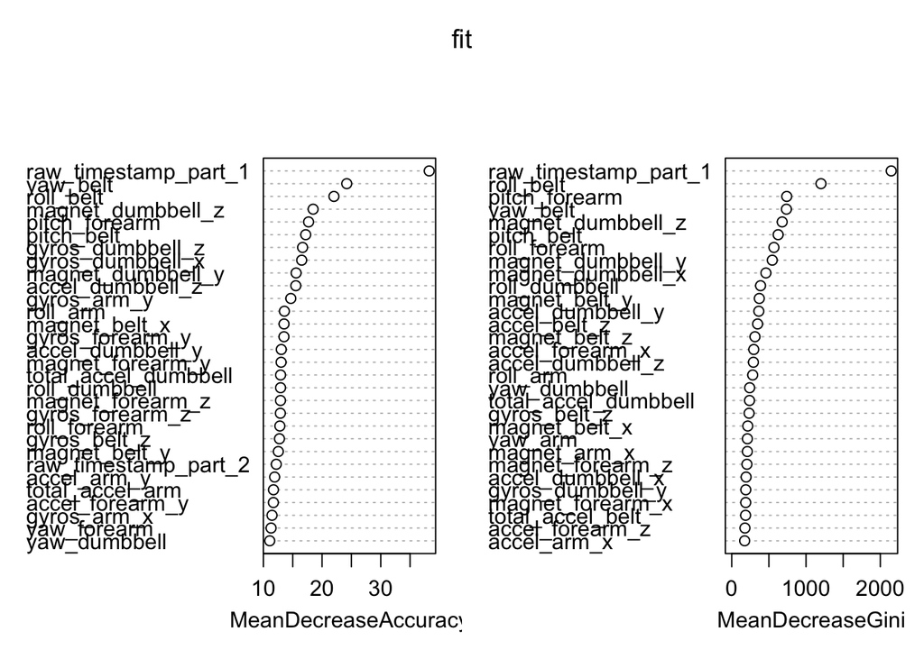

```r
varImpPlot(fit)
```

By plotting the model *fit*, we notice that after 25 trees, additional trees do not improve the accuracy.

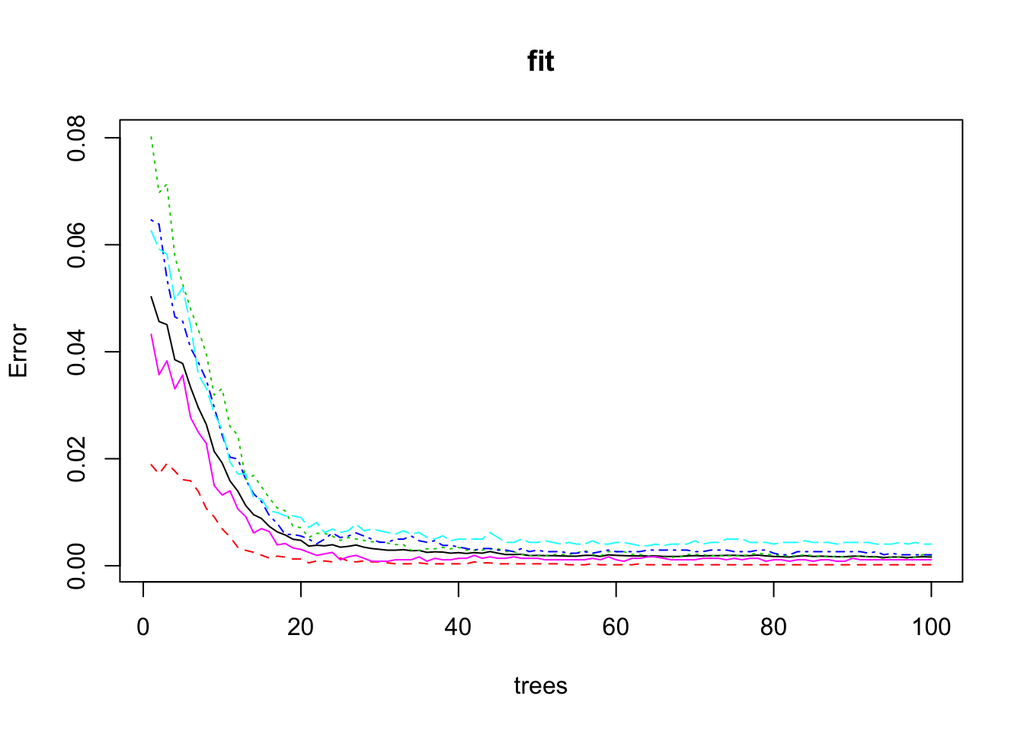

```r
plot(fit)
```

**Prediction**

Let us take a look at the probabilistic distribution of predicted values.

```r
predict(fit, filter_harTest, type = "prob")
```

```
##       A    B    C    D    E
## 1  0.04 0.87 0.08 0.01 0.00
## 2  0.95 0.03 0.02 0.00 0.00
## 3  0.12 0.80 0.05 0.00 0.03
## 4  0.97 0.01 0.02 0.00 0.00
## 5  0.99 0.00 0.01 0.00 0.00
## 6  0.00 0.05 0.08 0.02 0.85
## 7  0.00 0.01 0.02 0.96 0.01
## 8  0.09 0.75 0.08 0.07 0.01
## 9  1.00 0.00 0.00 0.00 0.00
## 10 0.99 0.00 0.00 0.01 0.00
## 11 0.03 0.85 0.08 0.03 0.01
## 12 0.00 0.00 0.97 0.00 0.03
## 13 0.01 0.98 0.00 0.01 0.00
## 14 1.00 0.00 0.00 0.00 0.00
## 15 0.00 0.01 0.01 0.00 0.98
## 16 0.01 0.00 0.00 0.00 0.99
## 17 1.00 0.00 0.00 0.00 0.00
## 18 0.05 0.93 0.00 0.02 0.00
## 19 0.05 0.93 0.01 0.01 0.00
## 20 0.00 1.00 0.00 0.00 0.00
## attr(,"class")
## [1] "matrix" "votes"
```

Finally let us take a look at the actual predictions.

```r
predict(fit, filter_harTest, type = "response")
```

```
##  1  2  3  4  5  6  7  8  9 10 11 12 13 14 15 16 17 18 19 20
##  B  A  B  A  A  E  D  B  A  A  B  C  B  A  E  E  A  B  B  B
## Levels: A B C D E
```